# Probability Distributions

2026-06-04

## Exploration: The Memoryless Property of the geometric Distribution

### Problem Context

The geometric distribution is uniquelly **memoryless**. Mathematically , if $Y$ represents the trial of the first success with probability $p$ , then for positive integers $a$ and $b$ :

$$P(Y > a + b \mid Y > a) = P(Y >
b)$$

This means that if we for example, flip a coint $a$ times, without a success, the probability that we need to flip it more that $b$ *additional* times is exactly the same as if we were flipping it $b$ times from the very beginning.

### The Objective

We will simulate a geometric process in R to empirically demonstrate this property.We will compare a baseline geometric distribution against a conditional distribution that has survived $a$ times.

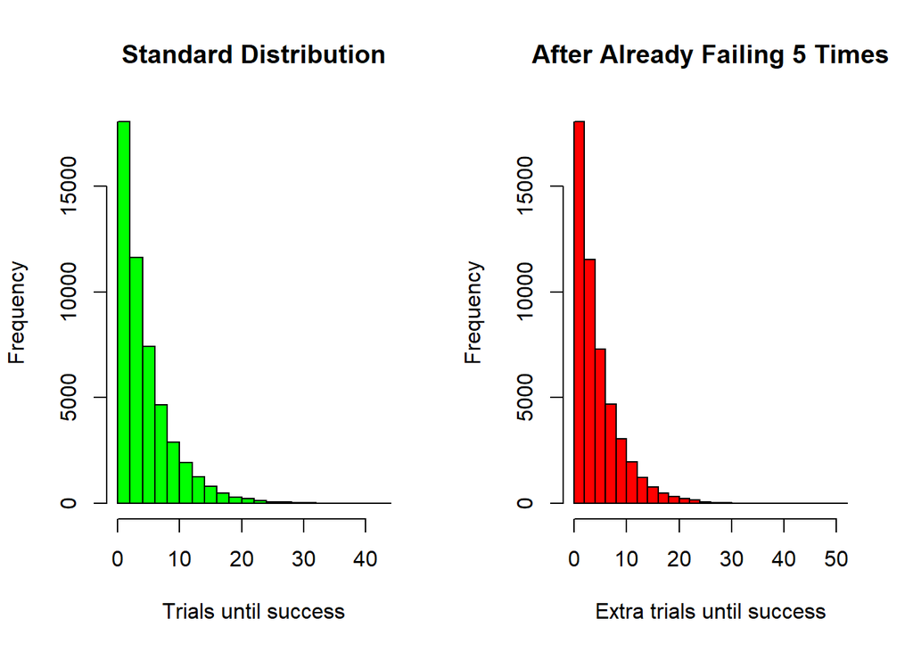

```r
# Set up variables
prob_success <- 0.2
cutoff <- 5
total_simulations <- 50000

# 1. Baseline: Standard geometric simulation
baseline <- rgeom(total_simulations, prob = prob_success) + 1

# 2. Conditional: Generate a large pool, then keep only the ones greater than our cutoff
large_pool <- rgeom(total_simulations * 5, prob = prob_success) + 1
survived <- large_pool[large_pool > cutoff]

# Take the first 50,000 that survived, and subtract the cutoff
extra_hidden_trials <- survived[1:total_simulations] - cutoff

# Split the plotting screen
par(mfrow =c(1,2))

# Plot 1: The Baseline
hist(baseline,
     breaks = 30,
     main = "Standard Distribution",
     xlab = "Trials until success",
     col = "green")

# Plot 2: The Extra Trials
hist(extra_hidden_trials,
     breaks = 30,
     main = "After Already Failing 5 Times",
     xlab = "Extra trials until success",
     col = "red")
```

### Conclusion

From the generated plots, we can visually observe that the distributions of both the baseline (non-conditional) trials and the shifted conditional trials are virtually identical.

### Why This Happens in Code

When we filtered our `large_pool` to only include games that lasted longer than our `cutoff` ($a = 5$), we isolated the simulations where a player experienced an initial streak of bad luck. By subtracting the cutoff from these survivors (`survived - cutoff`), we effectively reset their timeline back to “Time Zero.”

If the process had a “memory,” the players who already failed 5 times should show a different probability pattern moving forward. Instead, R’s random generation reveals that their remaining path looks exactly like a brand-new game.

### Connection to Exercise 3.71

This simulation provides empirical weight to the algebraic proof required in **Exercise 3.71**:

$$P(Y > a + b \mid Y > a) = P(Y >
b)$$